# ANLY 502 Project

Haoyu Wang, Zhuo Pan, Yannian Liu, Ming Cen

12/05/2022

### Index | Exploratory Data Analysis | NLP | ML | Conclusion

### Executive Summary

As seen in Figures 1 and 2, some factors are more important than others when predicting submission scores or controversiality. For example, the number of comments is important when predicting submission scores. On the other hand, flair, body text length, and submission score are more crucial factors when predicting controversiality scores.

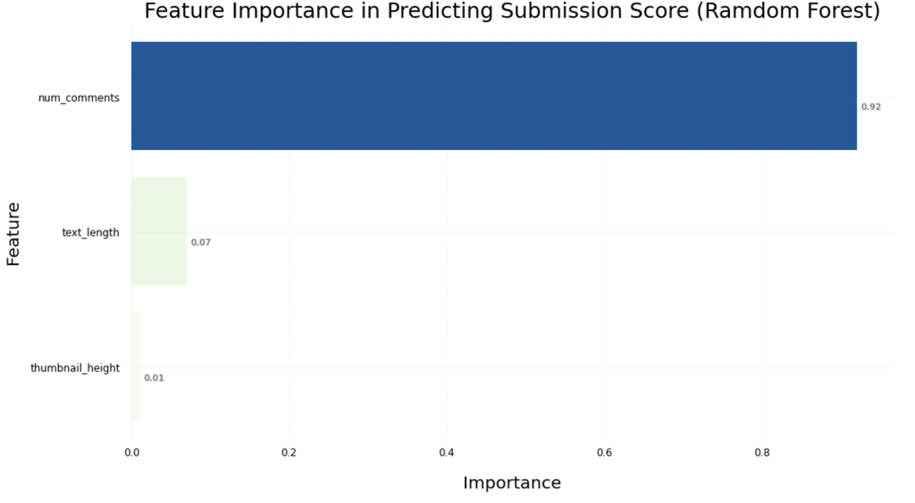

Figure 1 - Feature Importance of Predicting Submission Score

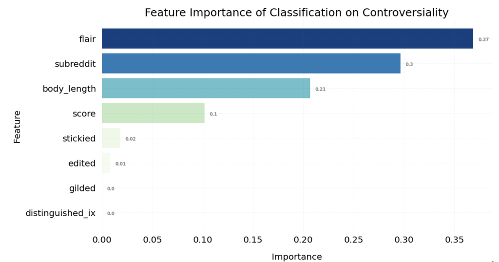

Figure 2 - Feature Importance of Classifying Comments Controversiality

### Analysis Report

#### Analysis 1: Predict Score of Submission by Random Forest & Decision Tree

With the business goal of seeking to accurately understand and predict user-product matching and submission quality rating, we would like to predict the score of Reddit submissions through two regression methods, using Random Forest Modeling and Decision Tree Modeling. The all rows of the submissions dataset is used, and the columns variables selected to be used to predict the score are num_comments (number of comments of submission post), thumbnail_height (the height of the thumbnail image of the submission) and selftext (which is the actual submission text).

For thumbnail_heights with 0, null is replaced by 0 to indicate the absence of a thumbnail. In addition, there are no null values in other columns. Therefore, no rows are dropped for null values. After cleaning the data, there are approximately 643 million rows in the dataset. We then create a new column called text_length that measures the no. of characters in variable selftext. Rows with text_length of 0 and 9 are dropped because 0 indicates an empty text while nine is associated with mostly the word [deleted]. After removing these rows, there are approximately 108 million rows left in the dataset. The standardization process is applied to the dataset to put all the variables in a technically comparable scale with standard deviation units. This allows us to process and compare values between different types of variables.

The cleaned and standardized dataset is then split into the train and test dataset for model training and model testing. A pipeline is created to perform the Random Forest and Decision Tree regression modeling. (This accounts for the bonus written in the instructions)

A random forest is used for the first model. In both figure 3 and table 2, we can see that num_comments (which is the number of comments) accounts for larger importance when predicting submission scores, while text_length and thumbnail_heights account for smaller importance when predicting submission scores.

[figure not shown]

Table 2 - Feature Importance in Predicting Submission Score (Random Forest)

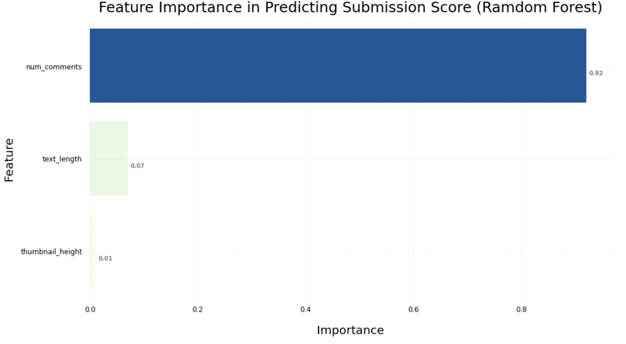

Figure 3 - Bar Graph Showing Feature Importance in Predicting Submission Score (Random Forest)

For the decision tree modeling, the same variables are used to predict the submission score. As seen from figure 4 and table 3, the importance of num_comments is higher than that of the random forest model. Respectively, the importance of text_length and thumbnail_height is less in the decision tree model than that in the random forest model.

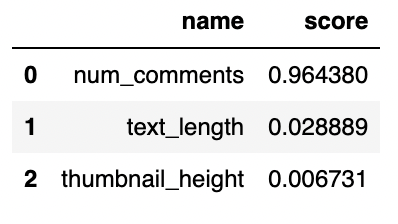

Table 3 - Feature Importance in Predicting Submission Score (Decision Tree)

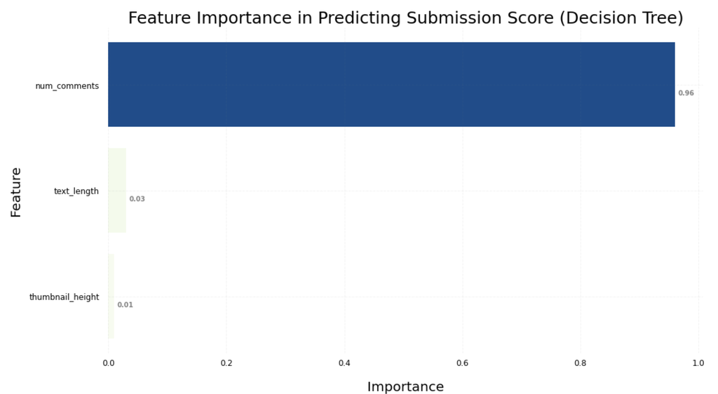

Figure 4 - Bar Graph Showing Feature Importance in Predicting Submission Score (Decision Tree)

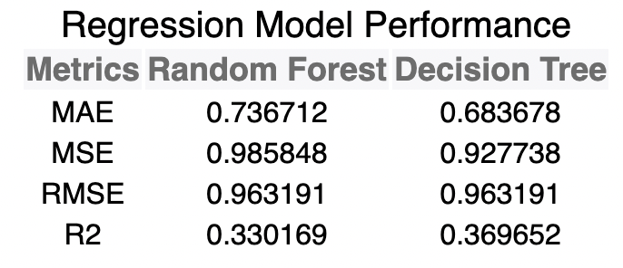

Table 4 - Performance of Regression Model Random Forest and Decision Tree

From the model results, we believe that the number of comments on submission is a good indicator of the submission score. In addition to the number of comments, the text length of the submission is also a contributor to predicting submission scores.

#### Analysis 2: Classification on Controversiality with Random Forest of 9 Variables versus 8 Variables

Using the comments dataset, nine variables are used to predict controversiality, which are ‘created_utc’, ‘subreddit’, ‘score’, ‘body’, ‘distinguished’, ‘edited’, ‘stickied’, ‘gilded’ and ‘author_flair_css_class’. Rows with null values are dropped, and rows that say ‘body’ for variable ‘body_length’ are also dropped. The comment dataset is then subset into a new dataset that includes only comments from the top 10 popular subreddits to in order to better predict controversiality as popularity ties in with controversiality. This is aimed to reach business goals 2, 5, 8 and 9.

There are approximately 2.09 million rows in the cleaned dataset. In addition, a pipeline is created for the machine learning transformation process. Undersampling algorithms are also used to better balance the class distribution for the classifcation dataset. The cleaned and undesampled dataset is then trained and tested via the first Random Forest model.

The second Random Forest model uses a different set of feature columns, totalling of 8 columns, which include ‘subreddit_vec’, ‘flair_vec’, ‘distinguished_ix’, ‘score’, ‘edited’, ‘stickied’, ‘gilded’, and ‘body_length’.

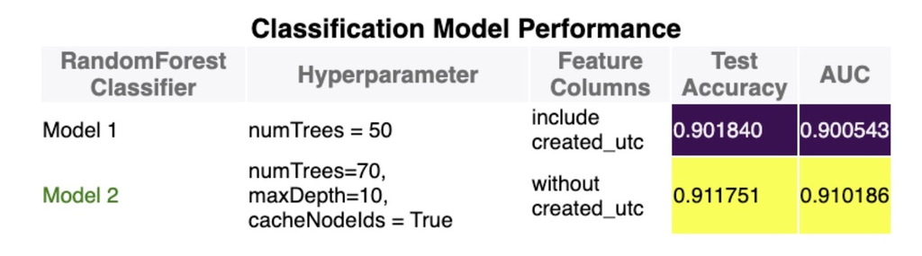

Table 5 - Model Performance of Classification on Controversiality Random Forest Model 1 and 2

Based on table 5 that shows the classification performance on controversiality in the two Random Forest models, we can see that model 2, without the created_utc column, performs better with both test accuracy and AUC score higher than model 1. Therefore, further visualizations will base on model 2.

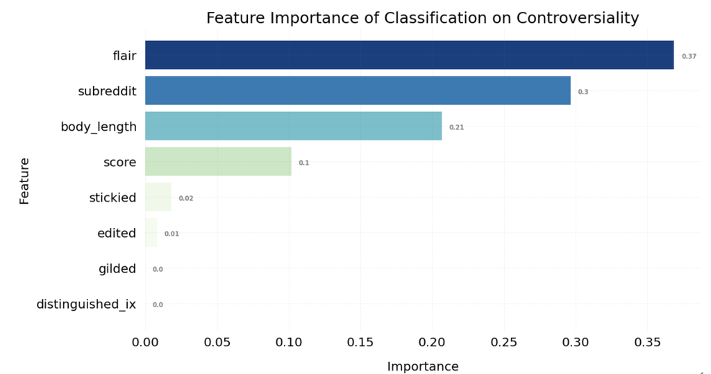

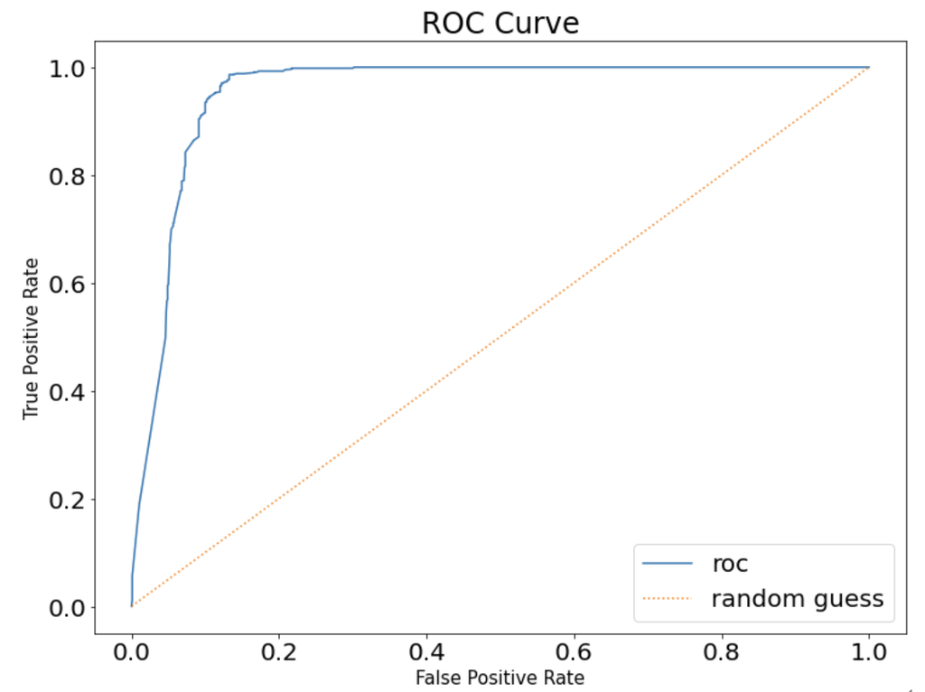

Figure 6 - ROC Curve for Classification of Controversiality Random Forest Model 2

#### Analysis 3: Comparison of Different Pretrained Models on Classification Sarcasm

Using the comments dataset, NLP processing is used to obtain sentiment of “normal” or “sarcasm” from comments in subreddit “Market76” and “CryptoCurrency”. Standardization is used to build a balanced dataset between normal and sarcasm sentiment rows. An embedding space is created while text rows of the dataset are tokenized for NLP processing. The dataset is then split into training and testing sets for modeling. Model 1 is a logistic regression with 10 iterations while model 2 is a logistic regression with 200 iterations.

The test set accuracy is higher for model 2, which is 0.92299, compared to 0.5. As seen in figure 7, the ROC curve of model 2 is significantly more optimal, which shows that it is going to better predict the sentiment and classification of sarcasm in comment data. This ties into business goals 8 and 9 where the classification of sarcasm may be useful in correctly defining and understanding the meaning of comments.

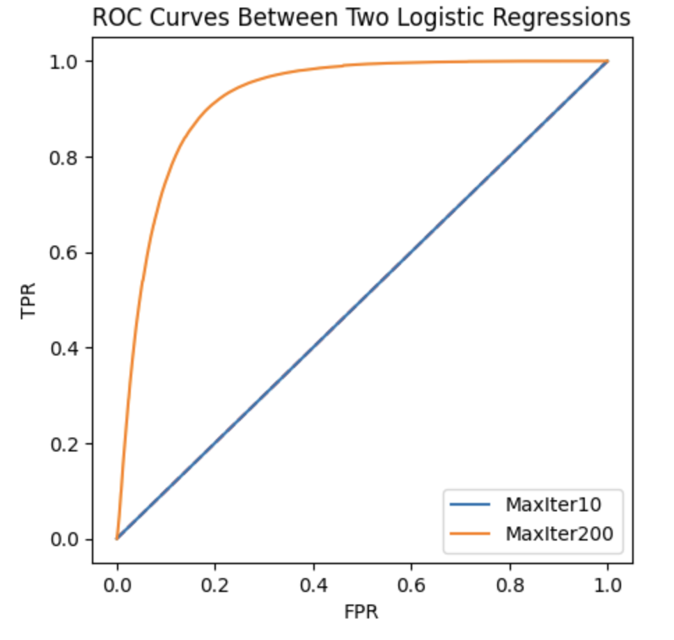

Figure 7 - ROC Curve for Logistic Regression Classification of Sarcasm